# CCtunnelFullAnalysis

# 1 Data exclusion

Load pre-processed data from Pavlovia and do data cleaning in accordance with criterion:  
(1)Individual trials with RT shorter than 200ms or exceeding the outlier threshold of remaining trials(3SD)  
(2)Subjects whose with average accuracy lower than 90% are cut off  
(3)RTs are only analyzed for correct responses  
(4)Bin 24 blocks in main experiment into 6 epochs to increase statistical power

Experimental design: 16 trials in each block, including 8 repeated config + 8 novel config; 25 blocks in total, including 20 training blocks + 4 testing blocks + 1 recognition task.

```r
rm(list = ls())
# read excel sheet with name
rawdataall <- read_excel("AllData_exp3.xlsx", sheet="Exp3RawData")
setDT(rawdataall)

# remove practice phase
rawdataall <- rawdataall[phase %in% c("training","testing","rt")]

# set names for presentation
setnames(rawdataall,"participant","Sub")
setnames(rawdataall,"CCCondition","Configuration")
setnames(rawdataall,"key_respMain.corr","Accuracy")
setnames(rawdataall,"key_respMain.rt","RT")
setnames(rawdataall,"phase","Phase")
setnames(rawdataall,"block","Block")
setnames(rawdataall,"targcell","Cell")

# convert into numeric
rawdataall$RT = as.numeric(rawdataall$RT)
rawdataall$Accuracy = as.numeric(rawdataall$Accuracy)
initial_count <- nrow(rawdataall)
###########################################################
# filter3: only accurate responses(get rid of table format)
tempdata = rawdataall
tempdata[,filter:=1][Accuracy==0,filter:=0]
excluded_count_acc <- sum(tempdata$filter == 0)
cat("Number of excluded trials based on Acc:", excluded_count_acc, "\n")
```

```
## Number of excluded trials based on Acc: 853
```

```r
###########################################################


## filter1: Individual trials remove based on RT
lowbound <- 0.2
# function to recursively remove outliers(typically 1 round only)
remove_RToutliers <- function(data, column_name, threshold_multiplier = 3, max_iterations = 1) {
  for (iteration in 1:max_iterations) {
    # Calculate mean and standard deviation
    mean_val <- mean(data[[column_name]])
    sd_val <- sd(data[[column_name]])

    # Set the threshold for outliers
    lower_threshold <- mean_val - threshold_multiplier * sd_val
    upper_threshold <- mean_val + threshold_multiplier * sd_val

    # Remove outliers
    data <- data %>% filter((data[[column_name]] > lower_threshold) & (data[[column_name]] < upper_threshold))
  }
  return(data)
}

# Remove outliers in RT for main exp but not recognition task -- continue on filter1
setDT(rawdataall)
tempdata <- rawdataall %>% filter((RT >= lowbound & Phase %in% c("training", "testing")) | !(Phase %in% c("training", "testing")))

tempdata <- tempdata %>% filter(Phase != "rt")
tempdata <- tempdata %>%
  group_by(Sub) %>%
  group_modify(~ remove_RToutliers(.x, "RT"))
tempdata <- bind_rows(tempdata, rawdataall %>% filter(Phase == "rt"))

excluded_count_rt <- initial_count - nrow(tempdata)
cat("Number of excluded trials based on RT:", excluded_count_rt, "\n")
```

```
## Number of excluded trials based on RT: 285
```

```r
# ## filter2: Individual blocks remove based on Acc(90% cutoff)
# accCutoff_data <- tempdata %>%
#   filter(Phase %in% c("training", "testing"))
#
# # Calculate mean accuracy
# sub_means <- accCutoff_data %>%
#   group_by(Sub, Configuration, Phase) %>%
#   summarise(mean_accuracy = mean(Accuracy)) %>%
#   group_by(Sub) %>%
#   summarise(mean_accuracy = mean(mean_accuracy))
#
#
# # Identify 'Sub' with mean accuracy less than 0.9
# subs_to_block <- sub_means %>%
#   filter(mean_accuracy < 0.9) %>%
#   pull(Sub)
#
# # Count and print the number of 'Sub' being ruled out
# num_subs_ruled_out <- length(subs_to_block)
# cat(paste("Number of Sub ruled out due to mean accuracy < 0.9 under both training and testing phases:", num_subs_ruled_out, "\n"))
#
# # Filter out the data for the 'Sub' that needs to be blocked
# cleaned_data <- data %>%
#   filter(!(Sub %in% subs_to_block))


##filter4: See in RT ANOVA
```

# 2 Accuracy

Check and basically plot: 1.Overall statistics for accuracy 2.two-way within-subject ANOVA on acc(If any speed-acc trade-offs with regard to configuration)

## 2.1 Averaged accuracy plotting

```r
# Plot 1
# ACC by config
tempdata <- as.data.table(tempdata)
accuracylong <- tempdata[, .(Accuracy=mean(Accuracy)),keyby=.(Sub, Configuration, Block, Phase)]
accuracylong$Sub = as.factor(accuracylong$Sub)
accuracylong$Configuration = as.factor(accuracylong$Configuration)
accuracylong$Block <- ifelse(accuracylong$Phase == "testing", accuracylong$Block + 20, accuracylong$Block)
accuracylong <- accuracylong %>% filter(Phase != "rt")

###################################################
## filter2: 90% cutoff for each Sub
mean_accuracy <- accuracylong %>%
  group_by(Sub) %>%
  mutate(mean_acc = mean(Accuracy))

Subs_cutoff <- mean_accuracy %>%
  distinct(Sub, mean_acc) %>%
  filter(mean_acc < 0.9) %>%
  pull(Sub)

num_subs_ruled_out <- length(Subs_cutoff)
cat(paste("Number of excluded subjects based on Accuracy:", num_subs_ruled_out, "\n"))
```

```
## Number of excluded subjects based on Accuracy: 0
```

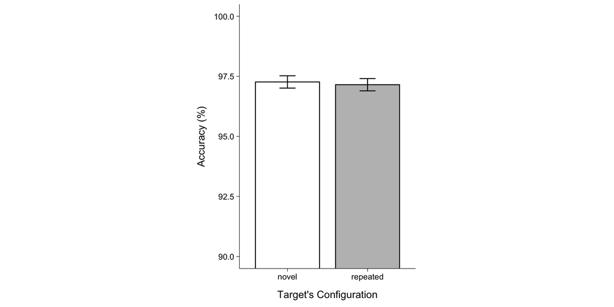

```r
###################################################

# Mean and within-subject SE
dfwc <- summarySEwithin(accuracylong, measurevar="Accuracy", withinvars=c("Configuration"),
                        idvar="Sub", na.rm=FALSE, conf.interval=.95)
# bar plot for acc
b_acc <- dfwc %>%
  ggplot(aes(x=factor(Configuration,levels=c("novel","repeated")),
             y=Accuracy*100,
             fill=factor(Configuration,levels=c("novel","repeated")))) +
  geom_bar(position=position_dodge(.9), fill = c("novel" = "white", "repeated" = "grey"), width=.8, colour="black", stat="identity") +
  geom_errorbar(position=position_dodge(.9), width=.2, aes(ymin=100*(Accuracy-se), ymax=100*(Accuracy+se))) +
  coord_cartesian(ylim=c(90,100)) +
  xlab("Target's Configuration") +
  ylab("Accuracy (%)") +
  theme_publish() +
  theme(legend.position="top",
        aspect.ratio = 1.5) +
  scale_fill_grey(start = 0.2, end = 0.6) +
  guides(fill=guide_legend(title="Configuration",nrow=1,byrow=TRUE))
print(b_acc)
```

## 2.2 Accuracy ANOVA

```r
##filter4: Binned into epochs
accuracylong <- as.data.table(accuracylong)
accuracylong[, Block := as.numeric(Block)]
accuracylong[, Epoch := cut(Block, breaks = c(0, 4, 8, 12, 16, 20, 25),
                        labels = c(1, 2, 3, 4, 5, 6), include.lowest = FALSE)]
accuracylong[, Epoch := as.numeric(Epoch)]
accuracylong$Epoch <- as.factor(accuracylong$Epoch)
accuracylong <- accuracylong[, .(Accuracy = mean(Accuracy)),
                     keyby = .(Sub,Configuration)]

# repeated ANOVA: Block * Configuration
options(contrasts=c('contr.sum','contr.poly'))
res.aov <- anova_test(
  data = accuracylong,
  dv = Accuracy,
  wid = Sub,
  within = Configuration,
  type = 3,
  effect.size = "pes"
)
# print ANOVA table
get_anova_table(res.aov,
                correction="none") %>%
  kbl(caption = "Accuracy: ANOVA on target's configuration") %>%
  row_spec(0,bold=TRUE) %>%
  kable_classic(full_width = F, html_font = "Arial",font_size = 16)
```

Accuracy: ANOVA on target’s configuration

| Effect | DFn | DFd | F | p | p<.05 | pes |
| --- | --- | --- | --- | --- | --- | --- |
| Configuration | 1 | 47 | 0.194 | 0.662 |  | 0.004 |

Overall accuracy is high for both configuration across epochs. The repeated ANOVA on accuracies indicates no potential speed-accuracy trade-offs regarding configuration type.

# 3 Search Time

Check and basically plot: 1.Overall statistics for RT by binned epoch 2.two-way within-subject ANOVA on RT

## 3.1 Averaged RT plots

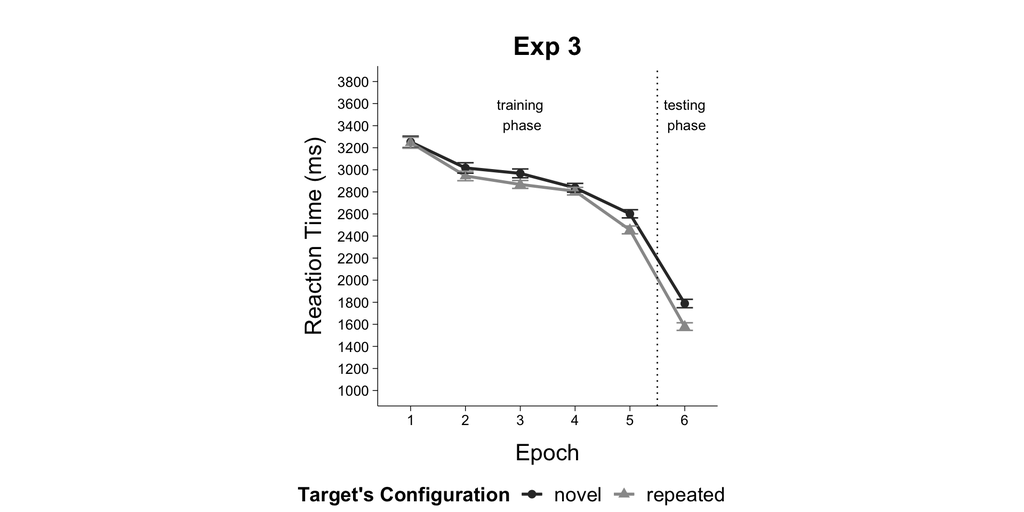

```r
##filter4: Correct trials only
# RT by Config across blocks(correct only)
RTlong <- tempdata[filter==1,
                     .(RT = mean(RT)),
                     keyby = .(Sub,Phase,Configuration,Block, Accuracy)]
RTlong$Sub <- as.factor(RTlong$Sub)
RTlong$Phase <- as.factor(RTlong$Phase)
RTlong$Configuration <- as.factor(RTlong$Configuration)
RTlong$Block <- as.factor(RTlong$Block)
RTlong <- RTlong %>% filter(Phase != "rt")

##filter4: Binned into epochs
RTlong <- as.data.table(RTlong)
RTlong[, Block := as.numeric(Block)]
RTlong$Block <- ifelse(RTlong$Phase == "testing", RTlong$Block + 20, RTlong$Block)
RTlong$Block <- RTlong$Block - 1
RTlong[, Epoch := cut(Block, breaks = c(0, 4, 8, 12, 16, 20, 25),
                        labels = c(1, 2, 3, 4, 5, 6), include.lowest = FALSE)]
RTlong[, Epoch := as.numeric(Epoch)]
RTlong$Epoch <- as.factor(RTlong$Epoch)

# within-subject SE
dfwc <- summarySEwithin(RTlong, measurevar="RT", withinvars=c("Phase","Configuration","Epoch"),
                        idvar="Sub", na.rm=FALSE, conf.interval=.95)
setDT(dfwc)

RT_all_exp <- dfwc %>%
  ggplot(aes(x=Epoch, y=RT*1000,
             colour=factor(Configuration,levels=c("novel","repeated")),
             group=factor(Configuration,levels=c("novel","repeated")))) +
  geom_line(size=1) +
  geom_point(aes(shape=factor(Configuration,levels=c("novel","repeated")),
                 color=factor(Configuration,levels=c("novel","repeated"))),size=2.5) +
  scale_y_continuous(breaks = seq(1000, 3800, by=200), limits=c(1000, 3800)) +
  geom_errorbar(width=.3, aes(ymin=(RT-se)*1000, ymax=(RT+se)*1000)) +
  xlab("Epoch") +
  ylab("Reaction Time (ms)") +
  scale_color_grey(start = 0.2, end = 0.6) +
  theme_publish() +
  geom_vline(xintercept = 5.5, linetype="dotted") +
  annotate("text", x=3, y=3500, label= "training\n phase", size=10/.pt) +
  annotate("text", x=6, y=3500, label= "testing\n phase", size=10/.pt) +
  labs(color = "Target's Configuration", shape = "Target's Configuration")+
  labs(title = "Exp 3") +
  theme(legend.position="top",
        aspect.ratio = 1)+
  theme(legend.text = element_text(size = 14), # legend font size
        legend.title=element_text(size=14), # legend title
        axis.text = element_text(size = 10), # axis text size
        axis.title = element_text(size = 16), # axis title size
        plot.title = element_text(size = 18,hjust = 0.5), # plot title size
  )



plot <- ggarrange(RT_all_exp, nrow=1,common.legend = TRUE,legend="bottom")
annotate_figure(plot, top = text_grob("",
                                      color = "black", face = "bold", size = 16))
```

```r
ggsave("Exp3RT.png", plot + theme_minimal() + theme(plot.background = element_rect(fill = "white")))
```

## 3.2 RT ANOVA

### 3.2.1 Configuration * Epoch

Experimental blocks are aggregated to 6 epochs, each containing 4 blocks.

```r
# RT by Config across blocks(correct only)
tempdata <- as.data.table(tempdata)
write.csv(tempdata, file = "RT_exp3.csv")
RTexp <- tempdata[filter==1,
                     .(RT = mean(RT)),
                     keyby = .(Sub,Phase,Configuration,Block)]
RTexp$Sub <- as.factor(RTexp$Sub)
RTexp$Phase <- as.factor(RTexp$Phase)
RTexp$Configuration <- as.factor(RTexp$Configuration)
RTexp$Block <- ifelse(RTexp$Phase == "testing", RTexp$Block + 20, RTexp$Block)
RTexp <- RTexp %>% filter(Phase != "rt")
RTexp$Block <- as.factor(RTexp$Block)

##filter4: Binned into epochs
RTexp <- as.data.table(RTexp)
RTexp[, Block := as.numeric(Block)]
RTexp[, Epoch := cut(Block, breaks = c(0, 4, 8, 12, 16, 20, 25),
                        labels = c(1, 2, 3, 4, 5, 6), include.lowest = FALSE)]
RTexp[, Epoch := as.numeric(Epoch)]
RTexp$Epoch <- as.factor(RTexp$Epoch)
RTexp <- RTexp[, .(RT = mean(RT)),
                     keyby = .(Sub,Configuration,Epoch)]

# repeated ANOVA for RT for main experiment
options(contrasts=c('contr.sum','contr.poly'))
res.aov <- anova_test(
  data = RTexp,
  dv = RT,
  wid = Sub,
  within = c(Configuration,Epoch),
  type = 3,
  effect.size = "pes"
)

# simple effect test
model <- aov(RT ~ Configuration * Epoch + Error(Sub), data = RTexp)
emm <- emmeans(model, ~ Configuration | Epoch)
comparisons <- pairs(emm)
print(comparisons)
```

```
## Epoch = 1:
##  contrast         estimate     SE  df t.ratio p.value
##  novel - repeated  0.00776 0.0733 517   0.106  0.9157
##
## Epoch = 2:
##  contrast         estimate     SE  df t.ratio p.value
##  novel - repeated  0.07238 0.0733 517   0.987  0.3241
##
## Epoch = 3:
##  contrast         estimate     SE  df t.ratio p.value
##  novel - repeated  0.10013 0.0733 517   1.365  0.1728
##
## Epoch = 4:
##  contrast         estimate     SE  df t.ratio p.value
##  novel - repeated  0.03072 0.0733 517   0.419  0.6755
##
## Epoch = 5:
##  contrast         estimate     SE  df t.ratio p.value
##  novel - repeated  0.14609 0.0733 517   1.992  0.0469
##
## Epoch = 6:
##  contrast         estimate     SE  df t.ratio p.value
##  novel - repeated  0.20889 0.0733 517   2.848  0.0046
```

```r
# print ANOVA table for main experiment
get_anova_table(res.aov,
                correction="none") %>%
  kbl(caption = "RT: ANOVA on target's configuration * epoch") %>%
  row_spec(0,bold=TRUE) %>%
  kable_classic(full_width = F, html_font = "Arial",font_size = 16)
```

RT: ANOVA on target’s configuration * epoch

Effect

DFn

DFd

F

p

p<.05

pes

Configuration

1

47

13.154

0.0007

0.219

Epoch

5

235

143.366

0.0000

0.753

Configuration:Epoch

5

235

2.119

0.0640

0.043

### ANOVA for 5th Epoch

```r
# Filter data for the 6th epoch
RTexp_epoch5 <- RTexp[Epoch == 5]

# ANOVA for RT for the 6th epoch (main effect of Configuration)
model_epoch5 <- anova_test(
  data = RTexp_epoch5,
  dv = RT,
  wid = Sub,
  within = Configuration,
  type = 3,
  effect.size = "pes"
)


# Cohen's d
repeated_5 <- RTexp_epoch5$RT[RTexp_epoch5$Configuration == "repeated"]
novel_5 <- RTexp_epoch5$RT[RTexp_epoch5$Configuration == "novel"]
cat("RT saving (s):", mean(novel_5) - mean(repeated_5), "\n")
```

```
## RT saving (s): 0.1461
```

```r
cat("saving percentage:", (mean(novel_5) - mean(repeated_5))/mean(novel_5), "\n")
```

```
## saving percentage: 0.05616
```

```r
# Print ANOVA table for the 5th epoch with PES
get_anova_table(model_epoch5,
                correction = "none") %>%
  kbl(caption = "RT: ANOVA on target's configuration (Epoch 5)") %>%
  row_spec(0, bold = TRUE) %>%
  kable_classic(full_width = F, html_font = "Arial", font_size = 16)
```

RT: ANOVA on target’s configuration (Epoch 5)

Effect

DFn

DFd

F

p

p<.05

pes

Configuration

1

47

7.846

0.007

0.143

```r
t_test_result <- t.test(RT ~ Configuration, data = RTexp_epoch5, paired = TRUE)
formatted_t_test_result <- lapply(t_test_result, function(x) if(is.numeric(x)) sprintf("%.3f", x) else x)

# Print the formatted result
print(t_test_result$statistic)
```

```
##     t
## 2.801
```

```r
cohen_d <- t_test_result$statistic/sqrt(length(unique(RTexp_epoch5$Sub[!is.na(RTexp_epoch5$Sub)])))
cat("Cohen's d:", cohen_d, "\n")
```

```
## Cohen's d: 0.4043
```

## 3.3 ANOVA for Testing Phase

```r
# Filter data for the 6th epoch
RTexp_epoch6 <- RTexp[Epoch == 6]

# ANOVA for RT for the 6th epoch (main effect of Configuration)
model_epoch6 <- anova_test(
  data = RTexp_epoch6,
  dv = RT,
  wid = Sub,
  within = Configuration,
  type = 3,
  effect.size = "pes"
)


# Cohen's d
repeated_6 <- RTexp_epoch6$RT[RTexp_epoch6$Configuration == "repeated"]
novel_6 <- RTexp_epoch6$RT[RTexp_epoch6$Configuration == "novel"]
cat("RT saving:", mean(novel_6) - mean(repeated_6), "\n")
```

```
## RT saving: 0.2089
```

```r
cat("saving percentage:", (mean(novel_6) - mean(repeated_6))/mean(novel_6), "\n")
```

```
## saving percentage: 0.1168
```

```r
# Print ANOVA table for the 5th epoch with PES
get_anova_table(model_epoch6,
                correction = "none") %>%
  kbl(caption = "RT: ANOVA on target's configuration (Epoch 6)") %>%
  row_spec(0, bold = TRUE) %>%
  kable_classic(full_width = F, html_font = "Arial", font_size = 16)
```

RT: ANOVA on target’s configuration (Epoch 6)

Effect

DFn

DFd

F

p

p<.05

pes

Configuration

1

47

38.15

0

0.448

```r
t_test_result <- t.test(RT ~ Configuration, data = RTexp_epoch6, paired = TRUE)
formatted_t_test_result <- lapply(t_test_result, function(x) if(is.numeric(x)) sprintf("%.3f", x) else x)

# Print the formatted result
print(t_test_result$statistic)
```

```
##     t
## 6.176
```

```r
cohen_d <- t_test_result$statistic/sqrt(length(unique(RTexp_epoch6$Sub[!is.na(RTexp_epoch6$Sub)])))
cat("Cohen's d:", cohen_d, "\n")
```

```
## Cohen's d: 0.8915
```

# 4 Awareness

To study the effect of explicit awareness of scene configuration repetition on RT, we convert the forced-choice recognition responses into d-prime.

## 4.1 Accuracy for each subject

```r
# RT accuracy for each subject
rtdata <- tempdata %>% filter(Phase == "rt")
rtdata <- as.data.table(rtdata)
accuracyAll <- rtdata[, .(Accuracy=mean(Accuracy)),keyby=.(Sub)]

# print table
accuracyAll %>%
  kbl(caption = "Accuracy of Recognition Task in each subject") %>%
  row_spec(0,bold=TRUE) %>%   kable_classic(full_width = F, html_font = "Arial",font_size = 16)
```

Accuracy of Recognition Task in each subject

| Sub | Accuracy |
| --- | --- |
| R_11YOUvLHEzUXzpI | 0.5000 |
| R_12RKA1jd9kB60sQ | 0.6875 |
| R_1FFBrN592v6e3lX | 0.5625 |
| R_1H8lYUTLMhawX2C | 0.7500 |
| R_1M4YiLOzSOWDyHG | 0.5625 |
| R_1Os0y60QOaJjBcT | 0.6875 |
| R_1OwqbzI1a04jQ3i | 0.6250 |
| R_1Ui7r8ygeRURFAv | 0.2500 |
| R_1eIUQO83DxkyNKA | 0.6875 |
| R_21hqhgHGHNt1mh3 | 0.5000 |
| R_233KVDGy1izcIHo | 0.4375 |
| R_2DNXxSv0ag65LaG | 0.5625 |
| R_2EDY6t9R3cQucir | 0.8125 |
| R_2EgYrPPi9IWrCkX | 0.6875 |
| R_2NjZfN59k0BiRCV | 0.4375 |
| R_2ONF404roAA3jox | 0.5000 |
| R_2YP3hcMmvTYfGpI | 0.2500 |
| R_2aW5qV1VoBHRZbx | 0.4375 |
| R_2dWR2tyXQb7UvQ5 | 0.6875 |
| R_2e4N7pRQdBzuBxR | 0.5625 |
| R_2f6PVQJkOaa6u9D | 0.5000 |
| R_2fNnJ16zkFFhfNk | 0.6250 |
| R_2qz96qiLvaIGgwC | 0.5625 |
| R_2t4KlYvyxWyNRwo | 0.7500 |
| R_2uES29IwFssAv3p | 0.6875 |
| R_2witvWKyOzSG2S8 | 0.6250 |
| R_2zMGA9hN8AFWuF5 | 0.5625 |
| R_2zTo1GKzJ8i9YkS | 0.6250 |
| R_31YigC7CWqNGsCj | 0.6250 |
| R_32a7BEuAIaQpj3u | 0.5625 |
| R_3FJdeGIjb9Shfb3 | 0.7500 |
| R_3JDeXa9jZAWo6Iy | 0.5000 |
| R_3KrW74lNi9PqiTU | 0.5000 |
| R_3NUopqHJU6BTsjj | 0.6250 |
| R_3QDJPszXE01nRF4 | 0.5625 |
| R_3RkjVriFh82yAec | 0.6875 |
| R_3hg872hkMWDkpKY | 0.4375 |
| R_3p4MPcST7D3Kecs | 0.5625 |
| R_6SxGpG10F1LRASL | 0.3750 |
| R_7UTD6nXc9BHB517 | 0.5000 |
| R_9ouLaI4a4vYuaCR | 0.5000 |
| R_AKv2LjDL7hBEoF3 | 0.6875 |
| R_D2kawbxAavvOhKp | 0.3750 |
| R_Pwx1OUsKx5fwFON | 0.5625 |
| R_RFGNdrfUTtQvvj3 | 0.6875 |
| R_To8sBxNrVBGWZrj | 0.6250 |
| R_szNn6A9tSdrWnIZ | 0.7500 |
| R_zZ6B5pYbAdzJGG5 | 0.8125 |

```r
# t-test
mean(accuracyAll$Accuracy)
```

```
## [1] 0.5794
```

```r
chance_level <- 0.5
t.test(accuracyAll$Accuracy, mu = chance_level)
```

```
##
##  One Sample t-test
##
## data:  accuracyAll$Accuracy
## t = 4.3, df = 47, p-value = 9e-05
## alternative hypothesis: true mean is not equal to 0.5
## 95 percent confidence interval:
##  0.5420 0.6168
## sample estimates:
## mean of x
##    0.5794
```

## 4.2 d-prime for each subject

```r
rtdata <- rtdata %>%
  mutate(
    hit = as.numeric(Accuracy == 1 & key_respMain.keys == "y"),
    false_alarm = as.numeric(Accuracy == 0 & key_respMain.keys == "y")
  )
hitAll <- rtdata[, .(hit=mean(hit)),keyby=.(Sub)]
faAll <- rtdata[, .(false_alarm=mean(false_alarm)),keyby=.(Sub)]
dAll <- merge(hitAll, faAll, by = "Sub", all = TRUE)

dAll <- as.data.table(dAll)
dAll[, dprime := qnorm(hit) - qnorm(false_alarm)]
dAll[, c("hit", "false_alarm") := NULL]

# print table
dAll %>%
  kbl(caption = "d-prime for each subject") %>%
  row_spec(0,bold=TRUE) %>%   kable_classic(full_width = F, html_font = "Arial",font_size = 16)
```

d-prime for each subject

| Sub | dprime |
| --- | --- |
| R_11YOUvLHEzUXzpI | 0.0000 |
| R_12RKA1jd9kB60sQ | 0.5685 |
| R_1FFBrN592v6e3lX | 0.3838 |
| R_1H8lYUTLMhawX2C | 0.8317 |
| R_1M4YiLOzSOWDyHG | 0.2127 |
| R_1Os0y60QOaJjBcT | 0.5685 |
| R_1OwqbzI1a04jQ3i | 0.6470 |
| R_1Ui7r8ygeRURFAv | -0.8317 |
| R_1eIUQO83DxkyNKA | 0.6616 |
| R_21hqhgHGHNt1mh3 | 0.0000 |
| R_233KVDGy1izcIHo | -0.1857 |
| R_2DNXxSv0ag65LaG | 0.1857 |
| R_2EDY6t9R3cQucir | 1.2155 |
| R_2EgYrPPi9IWrCkX | 0.5685 |
| R_2NjZfN59k0BiRCV | -0.1857 |
| R_2ONF404roAA3jox | 0.0000 |
| R_2YP3hcMmvTYfGpI | -0.7298 |
| R_2aW5qV1VoBHRZbx | -0.1701 |
| R_2dWR2tyXQb7UvQ5 | 0.5685 |
| R_2e4N7pRQdBzuBxR | 0.3838 |
| R_2f6PVQJkOaa6u9D | 0.0000 |
| R_2fNnJ16zkFFhfNk | 0.3984 |
| R_2qz96qiLvaIGgwC | 0.1701 |
| R_2t4KlYvyxWyNRwo | 0.8317 |
| R_2uES29IwFssAv3p | 0.6616 |
| R_2witvWKyOzSG2S8 | 0.3186 |
| R_2zMGA9hN8AFWuF5 | 0.1701 |
| R_2zTo1GKzJ8i9YkS | 0.3984 |
| R_31YigC7CWqNGsCj | 0.4759 |
| R_32a7BEuAIaQpj3u | 0.1573 |
| R_3FJdeGIjb9Shfb3 | 0.7298 |
| R_3JDeXa9jZAWo6Iy | 0.0000 |
| R_3KrW74lNi9PqiTU | 0.0000 |
| R_3NUopqHJU6BTsjj | 0.3984 |
| R_3QDJPszXE01nRF4 | 0.1573 |
| R_3RkjVriFh82yAec | 0.5685 |
| R_3hg872hkMWDkpKY | -0.2127 |
| R_3p4MPcST7D3Kecs | 0.2632 |
| R_6SxGpG10F1LRASL | -0.3315 |
| R_7UTD6nXc9BHB517 | 0.0000 |
| R_9ouLaI4a4vYuaCR | 0.0000 |
| R_AKv2LjDL7hBEoF3 | 0.5172 |
| R_D2kawbxAavvOhKp | -0.3559 |
| R_Pwx1OUsKx5fwFON | 0.1857 |
| R_RFGNdrfUTtQvvj3 | 0.5685 |
| R_To8sBxNrVBGWZrj | 0.3984 |
| R_szNn6A9tSdrWnIZ | 0.6745 |
| R_zZ6B5pYbAdzJGG5 | 0.9930 |

## 4.3 Awareness * Configuration * Phase ANOVA on RT saving

```r
# Construct RT saving on seeing repeated configurations
awardata = RTexp
awardata <- merge(awardata, dAll[, c("Sub", "dprime")], by = "Sub", all.x = TRUE)
awardata_novel <- awardata%>% filter(Configuration == "novel")
setDT(awardata_novel)
setnames(awardata_novel,"RT","RT_novel")

awardata_repeated <- awardata%>% filter(Configuration == "repeated")
setDT(awardata_repeated)
setnames(awardata_repeated,"RT","RT_repeated")

awardata_saving <- awardata_novel %>%
  inner_join(awardata_repeated, by = c("Sub", "Epoch", "dprime")) %>%
  mutate(RT_saving = RT_novel - RT_repeated) %>%
  dplyr::select(-starts_with("Configuration"), -RT_novel, -RT_repeated)

awardata_saving$Epoch <- as.numeric(awardata_saving$Epoch)

# Fit a mixed-effects model
awarmodel <- lmer(RT_saving ~ Epoch * dprime + (1 | Sub), data = awardata_saving, REML=F)
summary(awarmodel)
```

```
## Linear mixed model fit by maximum likelihood . t-tests use Satterthwaite's
##   method [lmerModLmerTest]
## Formula: RT_saving ~ Epoch * dprime + (1 | Sub)
##    Data: awardata_saving
##
##      AIC      BIC   logLik deviance df.resid
##    244.9    266.8   -116.4    232.9      282
##
## Scaled residuals:
##    Min     1Q Median     3Q    Max
## -4.021 -0.583 -0.010  0.592  4.552
##
## Random effects:
##  Groups   Name        Variance Std.Dev.
##  Sub      (Intercept) 0.0098   0.099
##  Residual             0.1231   0.351
## Number of obs: 288, groups:  Sub, 48
##
## Fixed effects:
##              Estimate Std. Error       df t value Pr(>|t|)
## (Intercept)   -0.0530     0.0588 270.9222   -0.90  0.36852
## Epoch          0.0492     0.0145 240.0000    3.41  0.00077 ***
## dprime         0.1182     0.1202 270.9222    0.98  0.32661
## Epoch:dprime  -0.0605     0.0296 240.0000   -2.05  0.04168 *
## ---
## Signif. codes:  0 '***' 0.001 '**' 0.01 '*' 0.05 '.' 0.1 ' ' 1
##
## Correlation of Fixed Effects:
##             (Intr) Epoch  dprime
## Epoch       -0.860
## dprime      -0.546  0.470
## Epoch:dprim  0.470 -0.546 -0.860
```

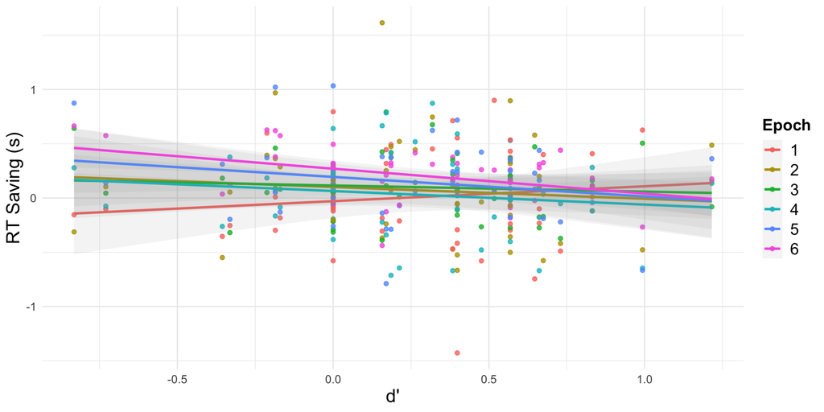

```r
# Visualize the interaction
(plot <- ggplot(awardata_saving, aes(x = dprime, y = RT_saving, color = as.factor(Epoch))) +
  geom_point(alpha = 0.8) +
  geom_smooth(method = "lm", alpha = 0.1) +
  labs(x = "d'", y = "RT Saving (s)", color = "Epoch") +
  theme_minimal() +
  theme(legend.text = element_text(size = 14), # legend font size
        legend.title=element_text(size=14, face = "bold"), # legend title
        axis.text = element_text(size = 10), # axis text size
        axis.title = element_text(size = 16), # axis title size
  ) )
```

```r
ggsave("Exp3Slopes.png", plot + theme(plot.background = element_rect(fill = "white")))
```

## 4.4 Correlation between RT saving in training phase and d’

```r
RTlong$Sub <- as.factor(RTlong$Sub)
RTlong$Phase <- as.factor(RTlong$Phase)
RTlong$Configuration <- as.factor(RTlong$Configuration)
RTlong$Block <- as.factor(RTlong$Block)
RT_half <- RTlong %>% filter(Phase != "testing")
RT_half$Block <- as.factor(RT_half$Block)
RT_half <- merge(RT_half, dAll[, c("Sub", "dprime")], by = "Sub", all.x = TRUE)
RT_half <- RT_half %>%
  filter(Block %in% c("11", "12", "13", "14", "15", "16", "17", "18", "19", "20"))
RT_half[, c("Phase", "Accuracy") := NULL]

# Construct RT saving
halfdata = RT_half
half_novel <- halfdata%>% filter(Configuration == "novel")
setDT(half_novel)
setnames(half_novel,"RT","RT_novel")

half_repeated <- halfdata%>% filter(Configuration == "repeated")
setDT(half_repeated)
setnames(half_repeated,"RT","RT_repeated")

half_saving <- half_novel %>%
  inner_join(half_repeated, by = c("Sub","Block","dprime")) %>%
  mutate(RT_saving = RT_novel - RT_repeated) %>%
  dplyr::select(-starts_with("Configuration"), -RT_novel, -RT_repeated)

# Convert necessary columns to numeric if needed
half_saving <- half_saving %>%
  mutate(dprime = as.numeric(dprime),
         RT_saving = as.numeric(RT_saving))

# Calculate correlation coefficients for each Block
correlations <- half_saving %>%
  # group_by(Block) %>%
  do(correlation = cor(.$RT_saving, .$dprime, use = "pairwise.complete.obs"))

correlations <- bind_rows(correlations)

# print table
correlations %>%
  kbl(caption = "r between RT savings and d for second-half training phase'") %>%
  row_spec(0,bold=TRUE) %>%   kable_classic(full_width = F, html_font = "Arial",font_size = 16)
```

r between RT savings and d for second-half training phase’

| correlation |
| --- |
| -0.07777 |

## 4.5 Correlation between RT saving and d’ in testing phase

```r
RTlong <- tempdata[filter==1,
                     .(RT = mean(RT)),
                     keyby = .(Sub,Phase,Configuration,Block, Accuracy)]
RTlong$Sub <- as.factor(RTlong$Sub)
RTlong$Phase <- as.factor(RTlong$Phase)
RTlong$Configuration <- as.factor(RTlong$Configuration)
RTlong$Block <- as.factor(RTlong$Block)
RT_half <- RTlong %>% filter(Phase != "training" & Phase != "rt")
RT_half$Block <- as.factor(RT_half$Block)
RT_half <- merge(RT_half, dAll[, c("Sub", "dprime")], by = "Sub", all.x = TRUE)
# RT_half <- RT_half %>%
#   filter(Block %in% c("11", "12", "13", "14", "15", "16", "17", "18", "19", "20"))
RT_half[, c("Phase", "Accuracy") := NULL]

# Construct RT saving for RT phase
halfdata = RT_half
half_novel <- halfdata%>% filter(Configuration == "novel")
setDT(half_novel)
setnames(half_novel,"RT","RT_novel")

half_repeated <- halfdata%>% filter(Configuration == "repeated")
setDT(half_repeated)
setnames(half_repeated,"RT","RT_repeated")

half_saving <- half_novel %>%
  inner_join(half_repeated, by = c("Sub","Block","dprime")) %>%
  mutate(RT_saving = RT_novel - RT_repeated) %>%
  dplyr::select(-starts_with("Configuration"), -RT_novel, -RT_repeated)

# Convert necessary columns to numeric if needed
half_saving <- half_saving %>%
  mutate(dprime = as.numeric(dprime),
         RT_saving = as.numeric(RT_saving))

# Calculate correlation coefficients in testing phase
correlations <- cor.test(half_saving$RT_saving, half_saving$dprime, method = "pearson", use = "pairwise.complete.obs")
p_value <- correlations$p.value
cat("p = ", p_value, "\n")
```

```
## p =  0.004872
```

```r
# Calculate correlation coefficients in testing phase
correlations <- half_saving %>%
  # group_by(Block) %>%
  do(correlation = cor(.$RT_saving, .$dprime, use = "pairwise.complete.obs"))

correlations <- bind_rows(correlations)

# print table
correlations %>%
  kbl(caption = "r between RT savings and d in testing phase'") %>%
  row_spec(0,bold=TRUE) %>%   kable_classic(full_width = F, html_font = "Arial",font_size = 16)
```

r between RT savings and d in testing phase’

| correlation |
| --- |
| -0.2024 |

## 4.6 Awareness(binned) * Configuration * Phase ANOVA

Categorize subjects whose d-prime > 0 as aware-group, and the other as unaware-group.

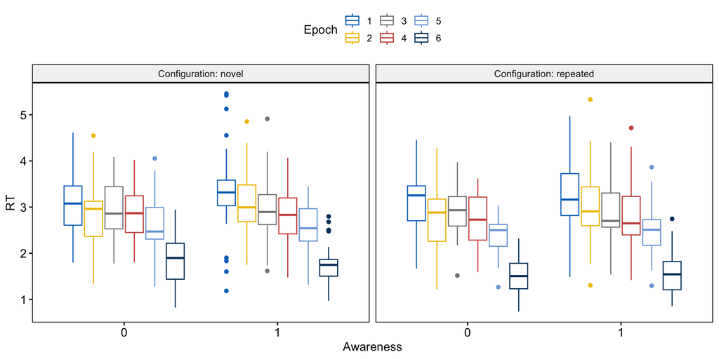

```r
# Convert dprime to yes/no
awardata_binned = RTexp
awardata_binned <- merge(awardata_binned, dAll[, c("Sub", "dprime")], by = "Sub", all.x = TRUE)
awardata_binned$Awareness <- ifelse(awardata_binned$dprime > 0, 1, 0)

bxp <- ggboxplot(
  awardata_binned, x = "Awareness", y = "RT",
  color = "Epoch", palette = "jco",
  facet.by = "Configuration", short.panel.labs = FALSE
  )
bxp
```

```r
res.aov <- anova_test(
  data = awardata_binned, dv = RT, wid = Sub,
  between = Awareness, within = c(Configuration, Epoch)
  )
get_anova_table(res.aov)
```

|  | Effect | DFn | DFd | F | p | p<.05 | ges |
| --- | --- | --- | --- | --- | --- | --- | --- |
| 1 | Awareness | 1.00 | 46.0 | 0.317 | 5.76e-01 |  | 0.005000 |
| 2 | Configuration | 1.00 | 46.0 | 13.629 | 5.89e-04 | * | 0.005000 |
| 3 | Epoch | 2.95 | 135.7 | 122.321 | 4.31e-38 | * | 0.326000 |
| 4 | Awareness:Configuration | 1.00 | 46.0 | 0.719 | 4.01e-01 |  | 0.000277 |
| 5 | Awareness:Epoch | 2.95 | 135.7 | 1.040 | 3.77e-01 |  | 0.004000 |
| 6 | Configuration:Epoch | 4.06 | 186.9 | 2.713 | 3.10e-02 | * | 0.003000 |
| 7 | Awareness:Configuration:Epoch | 4.06 | 186.9 | 0.987 | 4.17e-01 |  | 0.001000 |

## 4.7 Awareness(binned) * Phase ANOVA on RT saving

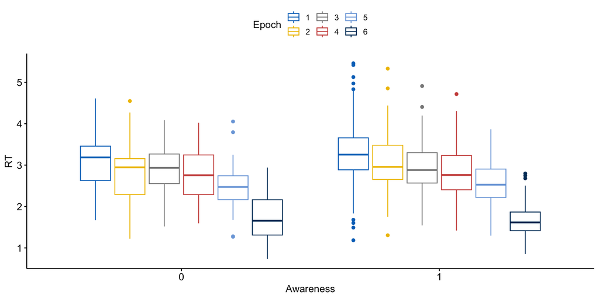

```r
# Convert dprime to yes/no
awardata_binned = RTexp
awardata_binned <- merge(awardata_binned, dAll[, c("Sub", "dprime")], by = "Sub", all.x = TRUE)
awardata_binned$Awareness <- ifelse(awardata_binned$dprime > 0, 1, 0)

awardata_novel <- awardata_binned%>% filter(Configuration == "novel")
setDT(awardata_novel)
setnames(awardata_novel,"RT","RT_novel")

awardata_repeated <- awardata_binned%>% filter(Configuration == "repeated")
setDT(awardata_repeated)
setnames(awardata_repeated,"RT","RT_repeated")

awardata_saving_binned <- awardata_novel %>%
  inner_join(awardata_repeated, by = c("Sub", "Epoch", "Awareness")) %>%
  mutate(RT_saving = RT_novel - RT_repeated) %>%
  dplyr::select(-starts_with("Configuration"), -RT_novel, -RT_repeated)



bxp <- ggboxplot(
  awardata_binned, x = "Awareness", y = "RT",
  color = "Epoch", palette = "jco",
  short.panel.labs = FALSE
  )
bxp
```

```r
res.aov <- anova_test(
  data = awardata_saving_binned, dv = RT_saving, wid = Sub,
  between = Awareness, within = c(Epoch)
  )
get_anova_table(res.aov)
```

|  | Effect | DFn | DFd | F | p | p<.05 | ges |
| --- | --- | --- | --- | --- | --- | --- | --- |
| 1 | Awareness | 1.00 | 46.0 | 0.719 | 0.401 |  | 0.004 |
| 2 | Epoch | 4.06 | 186.9 | 2.713 | 0.031 | * | 0.043 |
| 3 | Awareness:Epoch | 4.06 | 186.9 | 0.987 | 0.417 |  | 0.016 |

# 5 Z-score Search Time

## 5.1 Averaged Z-scored RT plots

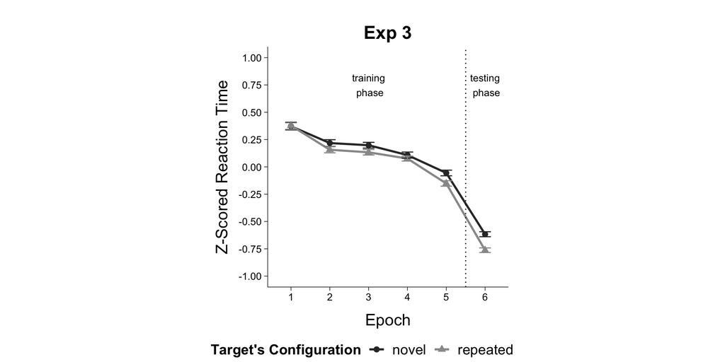

```r
# Construct new data(tempdata changed)
tempdata[, RT:=scale(RT), by=Sub]
RTnorm <- tempdata[filter==1,
                     .(RT = mean(RT)),
                     keyby = .(Sub,Phase,Configuration,Block, Accuracy)]
RTnorm$Sub <- as.factor(RTnorm$Sub)
RTnorm$Phase <- as.factor(RTnorm$Phase)
RTnorm$Configuration <- as.factor(RTnorm$Configuration)
RTnorm$Block <- as.factor(RTnorm$Block)
RTnorm <- RTnorm %>% filter(Phase != "rt")

##filter4: Binned into epochs
RTnorm <- as.data.table(RTnorm)
RTnorm[, Block := as.numeric(Block)]
RTnorm$Block <- ifelse(RTnorm$Phase == "testing", RTnorm$Block + 20, RTnorm$Block)
RTnorm$Block <- RTnorm$Block - 1
RTnorm[, Epoch := cut(Block, breaks = c(0, 4, 8, 12, 16, 20, 25),
                      labels = c(1, 2, 3, 4, 5, 6), include.lowest = FALSE)]
RTnorm[, Epoch := as.numeric(Epoch)]
RTnorm$Epoch <- as.factor(RTnorm$Epoch)


# within-subject SE
dfwc <- summarySEwithin(RTnorm, measurevar="RT", withinvars=c("Phase","Configuration","Epoch"),
                        idvar="Sub", na.rm=FALSE, conf.interval=.95)
setDT(dfwc)

RT_norm_exp <- dfwc %>%
  ggplot(aes(x=Epoch, y=RT,
             colour=factor(Configuration,levels=c("novel","repeated")),
             group=factor(Configuration,levels=c("novel","repeated")))) +
  geom_line(size=1) +
  geom_point(aes(shape=factor(Configuration,levels=c("novel","repeated")),
                 color=factor(Configuration,levels=c("novel","repeated"))),size=2.5) +
  scale_y_continuous(breaks = seq(-1, 1, by=0.25), limits=c(-1, 1)) +
  geom_errorbar(width=.3, aes(ymin=(RT-se), ymax=(RT+se))) +
  xlab("Epoch") +
  ylab("Z-Scored Reaction Time") +
  scale_color_grey(start = 0.2, end = 0.6) +
  theme_publish() +
  geom_vline(xintercept = 5.5, linetype="dotted") +
  annotate("text", x=3, y=0.75, label= "training\n phase", size=10/.pt) +
  annotate("text", x=6, y=0.75, label= "testing\n phase", size=10/.pt) +
  labs(color = "Target's Configuration", shape = "Target's Configuration")+
  labs(title = "Exp 3") +
  theme(legend.position="top",
        aspect.ratio = 1)+
  theme(legend.text = element_text(size = 14), # legend font size
        legend.title=element_text(size=14), # legend title
        axis.text = element_text(size = 10), # axis text size
        axis.title = element_text(size = 16), # axis title size
        plot.title = element_text(size = 18,hjust = 0.5), # plot title size
  )


plot <- ggarrange(RT_norm_exp, nrow=1,common.legend = TRUE,legend="bottom")
annotate_figure(plot, top = text_grob("",
                                      color = "black", face = "bold", size = 16))
```

```r
ggsave("Exp3RTStandard.png", plot + theme_minimal() + theme(plot.background = element_rect(fill = "white")))
```

## 5.2 Z-scored RT ANOVA

```r
# RT by Config across blocks(correct only)
tempdata <- as.data.table(tempdata)
write.csv(tempdata, file = "RTnorm_exp3.csv")
RTexp <- tempdata[filter==1,
                     .(RT = mean(RT)),
                     keyby = .(Sub,Phase,Configuration,Block)]
RTexp$Sub <- as.factor(RTexp$Sub)
RTexp$Phase <- as.factor(RTexp$Phase)
RTexp$Configuration <- as.factor(RTexp$Configuration)
RTexp$Block <- ifelse(RTexp$Phase == "testing", RTexp$Block + 20, RTexp$Block)
RTexp <- RTexp %>% filter(Phase != "rt")
RTexp$Block <- as.factor(RTexp$Block)

##filter4: Binned into epochs
RTexp <- as.data.table(RTexp)
RTexp[, Block := as.numeric(Block)]
RTexp[, Epoch := cut(Block, breaks = c(0, 4, 8, 12, 16, 20, 25),
                        labels = c(1, 2, 3, 4, 5, 6), include.lowest = FALSE)]
RTexp[, Epoch := as.numeric(Epoch)]
RTexp$Epoch <- as.factor(RTexp$Epoch)
RTexp <- RTexp[, .(RT = mean(RT)),
                     keyby = .(Sub,Configuration,Epoch)]

# repeated ANOVA for RT for main experiment
options(contrasts=c('contr.sum','contr.poly'))
res.aov <- anova_test(
  data = RTexp,
  dv = RT,
  wid = Sub,
  within = c(Configuration,Epoch),
  type = 3,
  effect.size = "pes"
)

# simple effect test
model <- aov(RT ~ Configuration * Epoch + Error(Sub), data = RTexp)
emm <- emmeans(model, ~ Configuration | Epoch)
comparisons <- pairs(emm)
print(comparisons)
```

```
## Epoch = 1:
##  contrast         estimate     SE  df t.ratio p.value
##  novel - repeated -0.00564 0.0472 517  -0.119  0.9050
##
## Epoch = 2:
##  contrast         estimate     SE  df t.ratio p.value
##  novel - repeated  0.06143 0.0472 517   1.300  0.1940
##
## Epoch = 3:
##  contrast         estimate     SE  df t.ratio p.value
##  novel - repeated  0.06469 0.0472 517   1.369  0.1715
##
## Epoch = 4:
##  contrast         estimate     SE  df t.ratio p.value
##  novel - repeated  0.03196 0.0472 517   0.676  0.4990
##
## Epoch = 5:
##  contrast         estimate     SE  df t.ratio p.value
##  novel - repeated  0.09622 0.0472 517   2.037  0.0422
##
## Epoch = 6:
##  contrast         estimate     SE  df t.ratio p.value
##  novel - repeated  0.14624 0.0472 517   3.096  0.0021
```

```r
# print ANOVA table for main experiment
get_anova_table(res.aov,
                correction="none") %>%
  kbl(caption = "RT: ANOVA on target's configuration * epoch") %>%
  row_spec(0,bold=TRUE) %>%
  kable_classic(full_width = F, html_font = "Arial",font_size = 16)
```

RT: ANOVA on target’s configuration * epoch

Effect

DFn

DFd

F

p

p<.05

pes

Configuration

1

47

14.705

0.0004

0.238

Epoch

5

235

162.620

0.0000

0.776

Configuration:Epoch

5

235

2.434

0.0360

0.049

### 5.2.1 Z-scored ANOVA for Training Phase Only

```r
# Filter data for epochs 1 to 5
RTexp_subset <- RTexp[Epoch %in% c(1, 2, 3, 4, 5)]

# Repeated ANOVA for RT for epochs 1 to 5
res.aov_subset <- anova_test(
  data = RTexp_subset,
  dv = RT,
  wid = Sub,
  within = c(Configuration, Epoch),
  type = 3,
  effect.size = "pes"
)

# Simple effect test for epochs 1 to 5
model_subset <- aov(RT ~ Configuration * Epoch + Error(Sub), data = RTexp_subset)

emm_subset1 <- emmeans(model_subset, ~ Configuration | Epoch)
comparisons_subset1 <- pairs(emm_subset1)
print(comparisons_subset1)
```

```
## Epoch = 1:
##  contrast         estimate     SE  df t.ratio p.value
##  novel - repeated -0.00564 0.0467 423  -0.121  0.9039
##
## Epoch = 2:
##  contrast         estimate     SE  df t.ratio p.value
##  novel - repeated  0.06143 0.0467 423   1.316  0.1890
##
## Epoch = 3:
##  contrast         estimate     SE  df t.ratio p.value
##  novel - repeated  0.06469 0.0467 423   1.385  0.1666
##
## Epoch = 4:
##  contrast         estimate     SE  df t.ratio p.value
##  novel - repeated  0.03196 0.0467 423   0.684  0.4941
##
## Epoch = 5:
##  contrast         estimate     SE  df t.ratio p.value
##  novel - repeated  0.09622 0.0467 423   2.061  0.0399
```

```r
emm_subset2 <- emmeans(model_subset, ~ Epoch | Configuration)
comparisons_subset2 <- pairs(emm_subset2)
print(comparisons_subset2)
```

```
## Configuration = novel:
##  contrast        estimate     SE  df t.ratio p.value
##  Epoch1 - Epoch2   0.1540 0.0467 423   3.299  0.0093
##  Epoch1 - Epoch3   0.1741 0.0467 423   3.728  0.0020
##  Epoch1 - Epoch4   0.2641 0.0467 423   5.656  <.0001
##  Epoch1 - Epoch5   0.4278 0.0467 423   9.163  <.0001
##  Epoch2 - Epoch3   0.0200 0.0467 423   0.429  0.9929
##  Epoch2 - Epoch4   0.1101 0.0467 423   2.357  0.1294
##  Epoch2 - Epoch5   0.2738 0.0467 423   5.864  <.0001
##  Epoch3 - Epoch4   0.0900 0.0467 423   1.928  0.3039
##  Epoch3 - Epoch5   0.2538 0.0467 423   5.435  <.0001
##  Epoch4 - Epoch5   0.1637 0.0467 423   3.507  0.0045
##
## Configuration = repeated:
##  contrast        estimate     SE  df t.ratio p.value
##  Epoch1 - Epoch2   0.2211 0.0467 423   4.735  <.0001
##  Epoch1 - Epoch3   0.2444 0.0467 423   5.234  <.0001
##  Epoch1 - Epoch4   0.3017 0.0467 423   6.461  <.0001
##  Epoch1 - Epoch5   0.5297 0.0467 423  11.344  <.0001
##  Epoch2 - Epoch3   0.0233 0.0467 423   0.498  0.9875
##  Epoch2 - Epoch4   0.0806 0.0467 423   1.726  0.4193
##  Epoch2 - Epoch5   0.3086 0.0467 423   6.609  <.0001
##  Epoch3 - Epoch4   0.0573 0.0467 423   1.227  0.7355
##  Epoch3 - Epoch5   0.2853 0.0467 423   6.110  <.0001
##  Epoch4 - Epoch5   0.2280 0.0467 423   4.883  <.0001
##
## P value adjustment: tukey method for comparing a family of 5 estimates
```

```r
# Print ANOVA table for epochs 1 to 5
get_anova_table(res.aov_subset,
                correction = "none") %>%
  kbl(caption = "RT: ANOVA on target's configuration * epoch (Epochs 1-5)") %>%
  row_spec(0, bold = TRUE) %>%
  kable_classic(full_width = F, html_font = "Arial", font_size = 16)
```

RT: ANOVA on target’s configuration * epoch (Epochs 1-5)

Effect

DFn

DFd

F

p

p<.05

pes

Configuration

1

47

6.412

0.015

0.120

Epoch

4

188

37.612

0.000

0.445

Configuration:Epoch

4

188

1.192

0.316

0.025

### 5.2.2 Z-scored ANOVA for 5th Epoch

```r
# Filter data for the 6th epoch
RTexp_epoch5 <- RTexp[Epoch == 5]

# ANOVA for RT for the 6th epoch (main effect of Configuration)
model_epoch5 <- anova_test(
  data = RTexp_epoch5,
  dv = RT,
  wid = Sub,
  within = Configuration,
  type = 3,
  effect.size = "pes"
)


# Cohen's d
repeated_5 <- RTexp_epoch5$RT[RTexp_epoch5$Configuration == "repeated"]
novel_5 <- RTexp_epoch5$RT[RTexp_epoch5$Configuration == "novel"]
cat("RT saving (units):", mean(novel_5) - mean(repeated_5), "\n")
```

```
## RT saving (units): 0.09622
```

```r
# Print ANOVA table for the 5th epoch with PES
get_anova_table(model_epoch5,
                correction = "none") %>%
  kbl(caption = "RT: ANOVA on target's configuration (Epoch 5)") %>%
  row_spec(0, bold = TRUE) %>%
  kable_classic(full_width = F, html_font = "Arial", font_size = 16)
```

RT: ANOVA on target’s configuration (Epoch 5)

Effect

DFn

DFd

F

p

p<.05

pes

Configuration

1

47

9.399

0.004

0.167

```r
t_test_result <- t.test(RT ~ Configuration, data = RTexp_epoch5, paired = TRUE)
formatted_t_test_result <- lapply(t_test_result, function(x) if(is.numeric(x)) sprintf("%.3f", x) else x)

# Print the formatted result
print(t_test_result$statistic)
```

```
##     t
## 3.066
```

```r
cohen_d <- t_test_result$statistic/sqrt(length(unique(RTexp_epoch5$Sub[!is.na(RTexp_epoch5$Sub)])))
cat("Cohen's d:", cohen_d, "\n")
```

```
## Cohen's d: 0.4425
```

### 5.2.3 ANOVA for Testing Phase

```r
# Filter data for the 6th epoch
RTexp_epoch6 <- RTexp[Epoch == 6]

# ANOVA for RT for the 6th epoch (main effect of Configuration)
model_epoch6 <- anova_test(
  data = RTexp_epoch6,
  dv = RT,
  wid = Sub,
  within = Configuration,
  type = 3,
  effect.size = "pes"
)


# Cohen's d
repeated_6 <- RTexp_epoch6$RT[RTexp_epoch6$Configuration == "repeated"]
novel_6 <- RTexp_epoch6$RT[RTexp_epoch6$Configuration == "novel"]
cat("RT saving (units):", mean(novel_6) - mean(repeated_6), "\n")
```

```
## RT saving (units): 0.1462
```

```r
# Print ANOVA table for the 6th epoch with PES
get_anova_table(model_epoch6,
                correction = "none") %>%
  kbl(caption = "RT: ANOVA on target's configuration (Epoch 6)") %>%
  row_spec(0, bold = TRUE) %>%
  kable_classic(full_width = F, html_font = "Arial", font_size = 16)
```

RT: ANOVA on target’s configuration (Epoch 6)

Effect

DFn

DFd

F

p

p<.05

pes

Configuration

1

47

42.89

0

0.477

```r
t_test_result <- t.test(RT ~ Configuration, data = RTexp_epoch6, paired = TRUE)
formatted_t_test_result <- lapply(t_test_result, function(x) if(is.numeric(x)) sprintf("%.3f", x) else x)

# Print the formatted result
print(t_test_result$statistic)
```

```
##     t
## 6.549
```

```r
cohen_d <- t_test_result$statistic/sqrt(length(unique(RTexp_epoch6$Sub[!is.na(RTexp_epoch6$Sub)])))
cat("Cohen's d:", cohen_d, "\n")
```

```
## Cohen's d: 0.9453
```

## 5.3 Z-scored ANOVA for Epoch 5-6

```r
# Filter data for the 6th epoch
RTexp_compa <- RTexp[Epoch %in% c(5,6)]

# ANOVA for RT for two epochs
model_compa <- anova_test(
  data = RTexp_compa,
  dv = RT,
  wid = Sub,
  within = c(Configuration, Epoch),
  type = 3,
  effect.size = "pes"
)


# Print ANOVA table for epochs 1 to 5
get_anova_table(model_compa,
                correction = "none") %>%
  kbl(caption = "RT: ANOVA on target's configuration * epoch (Epochs 5-6)") %>%
  row_spec(0, bold = TRUE) %>%
  kable_classic(full_width = F, html_font = "Arial", font_size = 16)
```

RT: ANOVA on target’s configuration * epoch (Epochs 5-6)

Effect

DFn

DFd

F

p

p<.05

pes

Configuration

1

47

33.352

0.000

0.415

Epoch

1

47

224.129

0.000

0.827

Configuration:Epoch

1

47

2.077

0.156

0.042

# 6 Individual difference

For repeated configuration, we check individual difference in awareness and its impact on RT in testing phase. Specifically, We examined the RT of identified and unidentified repeated configurations separately.

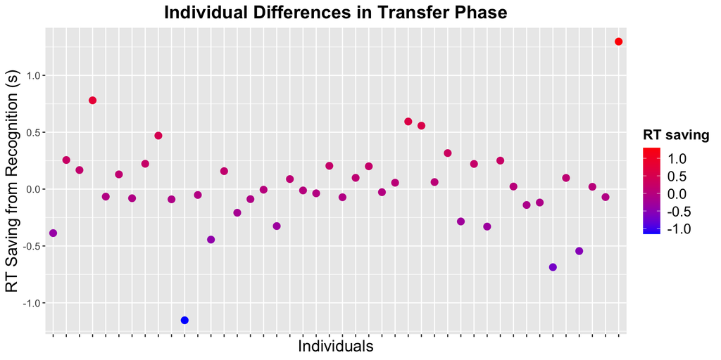

```r
##########################################
# read csv sheet with name
RTlong_exp3 <- read.csv("RT_exp3.csv")
RTnorm_exp3 <- read.csv("RTnorm_exp3.csv")


RTlong_exp3 <- RTlong_exp3 %>%
  mutate(Condition = "tunnel")
RTnorm_exp3 <- RTnorm_exp3 %>%
  mutate(Condition = "tunnel")

# merge data
RTlong <- RTlong_exp3
RTnorm <- RTnorm_exp3
##########################################

## Exp1
filtered_data <- RTlong_exp3 %>%
  filter(Phase == "rt" & Configuration == "repeated")

# Store the aware and unaware config for each Sub
filtered_data <- as.data.table(filtered_data)
filtered_data$configurationNumber = as.numeric(filtered_data$configurationNumber)

aware_data <- filtered_data %>%
  filter(Accuracy == 1) %>%
  dplyr::select(Sub, configurationNumber)

unaware_data <- filtered_data %>%
  filter(Accuracy == 0) %>%
  dplyr::select(Sub, configurationNumber)

# Group the data in testing phase
RT_testing <- RTlong %>%
  filter(Phase == "testing")

RT_aware <- RT_testing %>%
  semi_join(aware_data, by = c("Sub", "configurationNumber"))

RT_unaware <- RT_testing %>%
  semi_join(unaware_data, by = c("Sub", "configurationNumber"))

# Merge data based on recognition task
RT_aware <- RT_aware %>%
  mutate(recog = 1)
RT_unaware <- RT_unaware %>%
  mutate(recog = 0)
RT_indi <- rbind(RT_aware, RT_unaware)

# Plot RT saving from awareness
Sub_diff <- RT_indi %>%
  filter(filter == 1)
RT_aware <- as.data.table(RT_aware)
RT_unaware <- as.data.table(RT_unaware)

RT_aware <- RT_aware[filter == 1, .(RTaware=mean(RT)),keyby=.(Sub)]
RT_unaware <- RT_unaware[filter == 1, .(RTunaware=mean(RT)),keyby=.(Sub)]
RTall <- merge(RT_aware, RT_unaware, by = "Sub", all = TRUE)
RTall <- RTall[!is.na(RTaware) & !is.na(RTunaware)]
RTall[, RTcc := RTunaware - RTaware]

# Creating a scatter plot
(plot <- ggplot(RTall, aes(x = Sub, y = RTcc, color = RTcc)) +
  geom_point(size = 3) +
  scale_color_gradient(low = "blue", high = "red", name = "RT saving") +
  labs(x = "Individuals", y = "RT Saving from Recognition (s)", title = "Individual Differences in Transfer Phase") +
  theme(
    legend.text = element_text(size = 14),  # legend font size and bold
    legend.title = element_text(size = 14, face = "bold"),  # legend title and bold
    axis.text = element_text(size = 10),  # axis text size
    axis.title = element_text(size = 16),  # axis title size
    axis.text.x = element_blank(),  # hide x-axis labels
    plot.title = element_text(size = 18,hjust = 0.5, face = "bold"),
  ))
```

```r
ggsave("Exp3Indi.png", plot + theme(plot.background = element_rect(fill = "white")))

# ANOVA on RT saving
RT_indi <- as.data.table(RT_indi)
setnames(RT_indi,"recog","Recognition")
RT_indi$Recognition <- as.factor(RT_indi$Recognition)
RT_indi$Sub <- as.factor(RT_indi$Sub)
RT_indi <- RT_indi[, .(RT = mean(RT)),
                     keyby = .(Sub,Recognition)]

options(contrasts=c('contr.sum','contr.poly'))
res.aov <- anova_test(
data = RT_indi,
dv = RT,
wid = Sub,
within = Recognition,
type = 3,
effect.size = "pes"
)

# print ANOVA table for testing
get_anova_table(res.aov,
                correction="none") %>%
  kbl(caption = "RT: ANOVA on recognition of repeated configuration") %>%
  row_spec(0,bold=TRUE) %>%
  kable_classic(full_width = F, html_font = "Arial",font_size = 16)
```

RT: ANOVA on recognition of repeated configuration

| Effect | DFn | DFd | F | p | p<.05 | pes |
| --- | --- | --- | --- | --- | --- | --- |
| Recognition | 1 | 43 | 0.099 | 0.755 |  | 0.002 |

```r
recognized_stats <- RT_indi[Recognition == 1, .(mean = mean(RT*1000), se = sd(RT*1000)/sqrt(.N))]
unrecognized_stats <- RT_indi[Recognition == 0, .(mean = mean(RT*1000), sd = sd(RT*1000)/sqrt(.N))]

# Print the results
cat("Stats for recognized old:\n")
```

```
## Stats for recognized old:
```

```r
print(recognized_stats)
```

```
##    mean    se
## 1: 1581 68.97
```

```r
cat("\nStats for unrecognized old:\n")
```

```
##
## Stats for unrecognized old:
```

```r
print(unrecognized_stats)
```

```
##    mean    sd
## 1: 1570 85.47
```